# Targeting A Housing Subsidy

Yingxue Ou

Nov 2,2022

# 1 Introduction

This project aims to help the Department of Housing and Community Development (HCD) target household who qualify for a home tax credit program and maximum the revenue that brought by those qualified households. Given a random sample of records with household’s age, jobs and marital etc., variables that might associated with their qualifications of home tax credit, a logistic regression model is generated to predict individuals will enter the program or not. As the cost/benefit of each individuals in confusion metrics can be calculated, the prediction results will be used to inform a cost/benefit analysis.

# 2 Set up

```r
options(scipen=10000000)
library(tidyverse)
library(kableExtra)
library(caret)
library(knitr)
library(pscl)
library(plotROC)
library(pROC)
library(lubridate)
library(scales)

root.dir = "https://github.com/urbanSpatial/Public-Policy-Analytics-Landing/raw/master/DATA/"
source("https://raw.githubusercontent.com/urbanSpatial/Public-Policy-Analytics-Landing/master/functions.r")

palette5 <- c("#981FAC","#CB0F8B","#FF006A","#FE4C35","#FE9900")
palette4 <- c("#981FAC","#FF006A","#FE4C35","#FE9900")
palette2 <- c("#981FAC","#FF006A")

Subsidy <- read.csv(file.path(root.dir,"Chapter6/housingSubsidy.csv")) %>%
  mutate(CreditNumeric = as.factor(ifelse(y == "yes", 1, 0))) %>%
  na.omit()

Subsidy <- subset(Subsidy, taxLien != 'yes')



corTheme <- function(base_size = 10, title_size = 12, small_size = 8){
  theme(axis.text =  element_blank(),
        axis.ticks = element_blank(),
        text = element_text(size = 10),
        panel.background = element_rect(fill = greyPalette5[1]),
        axis.title.x = element_text(size = small_size),
        axis.title.y = element_text(size = small_size),
        plot.subtitle = element_text(hjust = 0.5, size = base_size),
        plot.title = element_text(hjust = 0.5, size = title_size),
        plot.caption=element_text(size = small_size, colour = "black", hjust = 0.5))
}
```

In the code block above, `y` indicates the individual enter the program or not, the outcome is recoded to a binary, `0` and `1` variable called `CreditNumeric`. Any field with `NA` is removed from the data.

# 3 Data Exploration

In this section, the data is explored by visualizing correlation between `y` and the predictive features. As for the dependent variable `y` is binary, with two possible outcomes, it is better to plot features grouped by `y` which exhibit significant differences across the `yes` or `no` outcomes.

## 3.1 Feature importance

Figure 3-1 plots the mean for 7 continuous features grouped by `y`. It seems that the `age`, `cons.conf.idx`, `cons.price.idx` and `spent_on_repairs` have no influence in household’s choice of whether to enter the program or not. While, contacts with lower US inflation rate or unemployment rate, or who were contacts before this campaign for this ind. tend to enter the program.

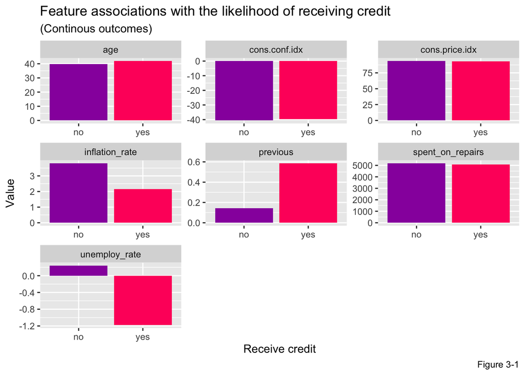

```r
Subsidy %>%
  dplyr::select(y,age, previous, unemploy_rate, cons.price.idx, cons.conf.idx, inflation_rate, spent_on_repairs) %>%
  gather(Variable, value, -y) %>%
    ggplot(aes(y, value, fill=y)) +
      geom_bar(position = "dodge", stat = "summary", fun = "mean") +
      facet_wrap(~Variable, scales = "free") +
      scale_fill_manual(values = palette2) +
      labs(x="Receive credit", y="Value",
           title = "Feature associations with the likelihood of receiving credit",
           subtitle = "(Continous outcomes)",
           caption = "Figure 3-1") +
      theme(legend.position = "none")
```

Most of the features are categorical. Figure 3-2 and 3-3 illustrate whether differences in household factors associate with the likelihood that they will receive credit or not. The `count` function calculates the total number of customers reported as `yes` for a given feature.

The interpretation for Figure 3-2 is that more household who receive the credit tend to be contacted by cellular, with full-time residence in Philadelphia.

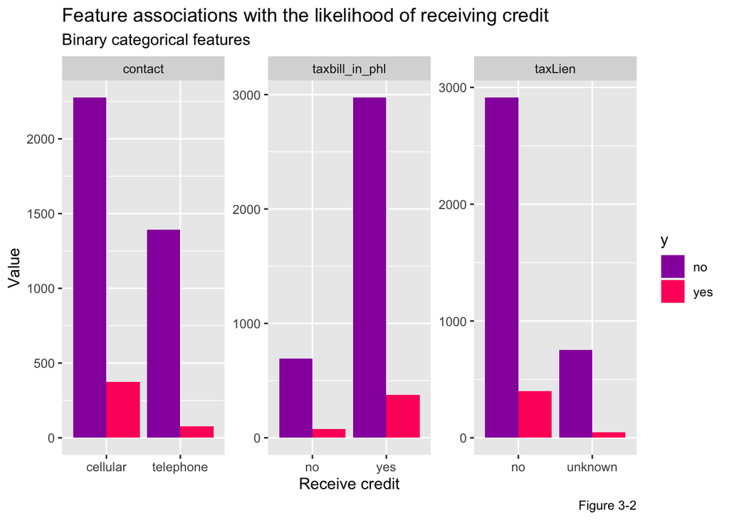

```r
Subsidy %>%
    dplyr::select(y, taxbill_in_phl, contact, taxLien) %>%
    gather(Variable, value, -y) %>%
    count(Variable, value, y) %>%
      ggplot(., aes(value, n, fill = y)) +
        geom_bar(position = "dodge", stat="identity") +
        facet_wrap(~Variable, scales="free") +
        scale_fill_manual(values = palette2) +
        labs(x="Receive credit", y="Value",
             title = "Feature associations with the likelihood of receiving credit",
             subtitle = "Binary categorical features",
             caption = "Figure 3-2")
```

```r
#        theme(axis.text.x = element_text(angle = 45, hjust = 1))
```

Figure 3-3 plots multiple category associations.

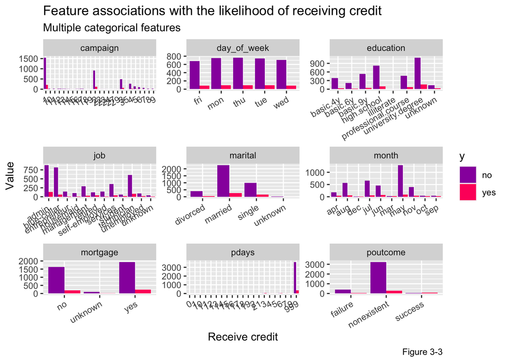

```r
Subsidy %>%
    dplyr::select(y, job, education, mortgage, month, day_of_week, poutcome, marital, campaign, pdays) %>%
    gather(Variable, value, -y) %>%
    count(Variable, value, y) %>%
      ggplot(aes(value, n, fill = y)) +
        geom_bar(position = "dodge", stat="identity") +
        facet_wrap(~Variable, scales= "free", ncol = 3) +
        scale_fill_manual(values = palette2) +
        labs(x="Receive credit", y="Value",
             title = "Feature associations with the likelihood of receiving credit",
             subtitle = "Multiple categorical features",
             caption = "Figure 3-3") +
        theme(axis.text.x = element_text(angle = 30, hjust = 1))
```

## 3.2 Feature correlation

Figure 3-4, 3-5 and 3-6 plots correlation of continuous, binary catrgorical and multiple categorical variables, respectively.

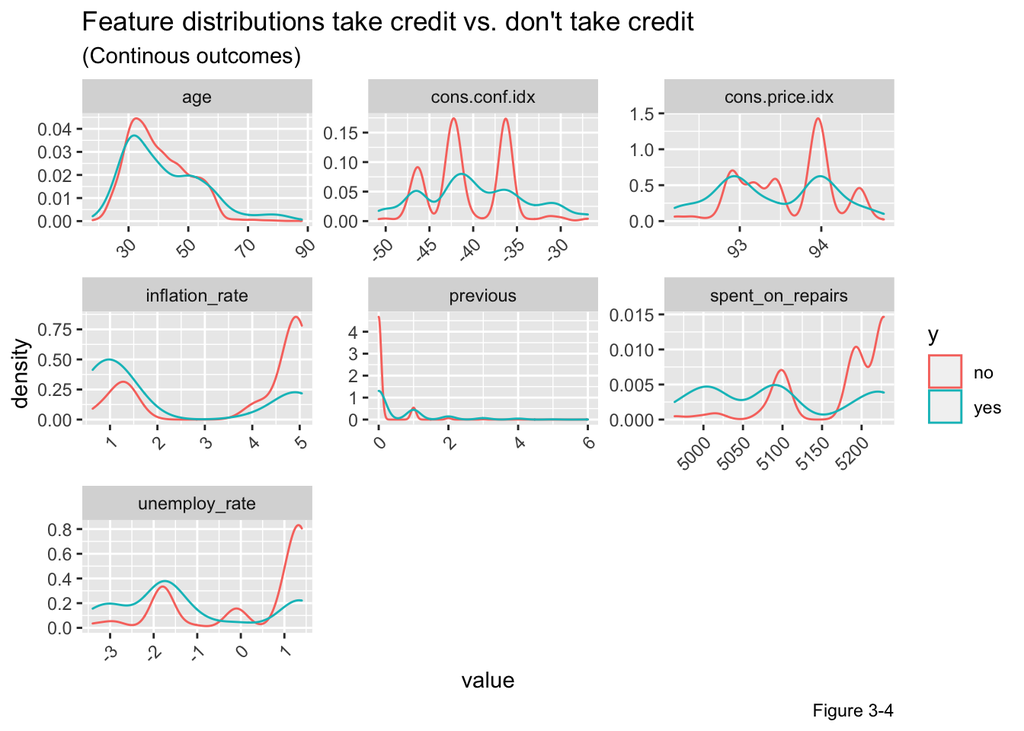

```r
Subsidy %>%
    dplyr::select(y,age, previous, unemploy_rate, cons.price.idx, cons.conf.idx, inflation_rate, spent_on_repairs) %>%
    gather(Variable, value, -y) %>%
    ggplot() +
    geom_density(aes(value, color=y), fill = "transparent") +
    facet_wrap(~Variable, scales = "free") +
    scale_fill_manual(values = palette2) +
    labs(title = "Feature distributions take credit vs. don't take credit",
         subtitle = "(Continous outcomes)",
         caption = "Figure 3-4")+
  theme(axis.text.x = element_text(angle = 45, hjust = 1))
```

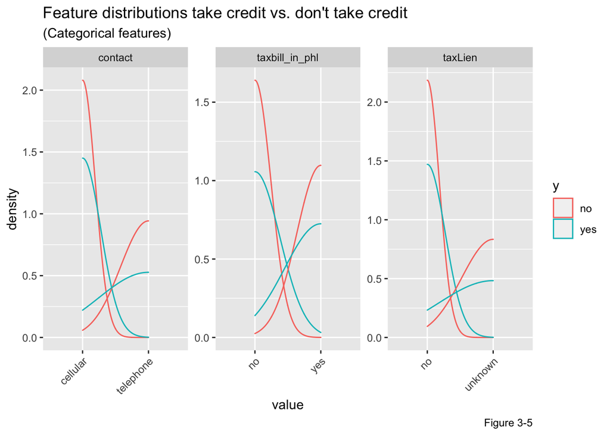

```r
Subsidy %>%
    dplyr::select(y, taxbill_in_phl, contact, taxLien) %>%
    gather(Variable, value, -y) %>%
    ggplot() +
    geom_density(aes(value, color=y), fill = "transparent") +
    facet_wrap(~Variable, scales = "free", ncol = 3) +
    scale_fill_manual(values = palette2) +
    labs(title = "Feature distributions take credit vs. don't take credit",
         subtitle = "(Categorical features)",
         caption = "Figure 3-5")+
  theme(axis.text.x = element_text(angle = 45, hjust = 1))
```

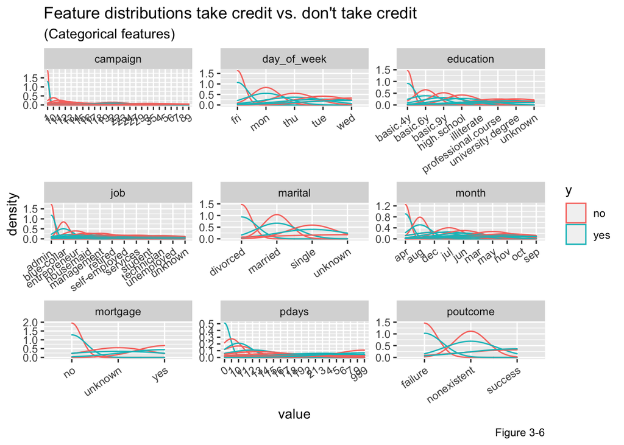

```r
Subsidy %>%
    dplyr::select(y, job, education, mortgage, month, day_of_week, poutcome, marital, campaign, pdays) %>%
    gather(Variable, value, -y) %>%
    ggplot() +
    geom_density(aes(value, color=y), fill = "transparent") +
    facet_wrap(~Variable, scales = "free", ncol = 3) +
    scale_fill_manual(values = palette2) +
    labs(title = "Feature distributions take credit vs. don't take credit",
         subtitle = "(Categorical features)",
         caption = "Figure 3-6")+
  theme(axis.text.x = element_text(angle = 35, hjust = 1))
```

## 3.3 Feature transformations

For there are too many categories in `education` and `month`, I create two variables `Education` and `Season` to store the reclassify results of `education` and `month`. Moreover, I classify `pdays` and `age` to use categorical variables rather than continuous variable.

```r
Subsidy <-
  Subsidy %>%
  # Education reclassify
  mutate(
    Education = case_when(education == "basic.9y"|education == "basic.4y"|education == "basic.6y" ~ "basic",
                                   education == "high.school" ~ "highschool",
                                   education == "university.degree" ~ "university",
                                   education == "professional.course" ~ "professional",
                                   education == "unknown" ~ "unknown",
                                   education == "illiterate" ~ "illiterate"
      )
 ) %>%
  # Month reclassified to season
  mutate(
    Season = case_when(
      month == "dec"|month == "jan"|month=="feb" ~ "winter",
      month == "mar"|month == "apr"|month=="may" ~ "spring",
      month == "jun"|month == "jul"|month=="aug" ~ "summer",
      month == "sep"|month == "oct"|month=="nov" ~ "fall"
    )
  ) %>%
  # Previous reclassify
   mutate(
    Contact = case_when(
      pdays == 999 ~ "No Contact",
      pdays < 7 ~" One week",
      pdays >= 7 &pdays <14 ~" Two weeks",
      pdays >= 15 &pdays <21 ~" Three weeks",
      pdays >= 22 ~" More than three weeks"
    )
  ) %>%
  # Age reclassify
  mutate(
    Age = case_when(
      age >= 18 & age < 25 ~"Gen Z",
      age >= 26 & age < 41 ~"Millenials",
      age >= 42 & age < 57 ~"Gen X",
      TRUE ~ "Boomer"
    )
  )
```

# 4 Regression Model

In this section, I will create Logistic regression model which is based on Maximum Likelihood Estimation. The logistic regression is estimated with `glm` function, in code chunks below, features will be delected by `select` operation in `glm`.

## 4.1 Split train/test set

Firstly, I partition data into a 65/35 training and test set `(p = 0.65)` and named them as `SubsidyTrain` and `SubsidyTest`.

```r
set.seed(3456)
trainIndex <- createDataPartition(Subsidy$y, p = .65,
                                  list = FALSE,
                                  times = 1)
SubsidyTrain <- Subsidy[ trainIndex,]
SubsidyTest  <- Subsidy[-trainIndex,]
```

## 4.2 Create a logistic regression model

Here I run model named as `SubsidyModel1` with the dependent variable `CreditNumeric` and I used all variables before transformation in the regression.

```r
SubsidyModel1 <- glm(CreditNumeric ~ .,
                  data=SubsidyTrain %>%
                    dplyr::select(-X, -y, -y_numeric, -Education, -Season, -Contact, -Age),
                  family="binomial" (link="logit"))

summary(SubsidyModel1)
```

```
##
## Call:
## glm(formula = CreditNumeric ~ ., family = binomial(link = "logit"),
##     data = SubsidyTrain %>% dplyr::select(-X, -y, -y_numeric,
##         -Education, -Season, -Contact, -Age))
##
## Deviance Residuals:
##     Min       1Q   Median       3Q      Max
## -2.1855  -0.4124  -0.3355  -0.2591   2.7719
##
## Coefficients:
##                                  Estimate   Std. Error z value Pr(>|z|)
## (Intercept)                   -74.2894054  127.7455033  -0.582  0.56088
## age                             0.0105729    0.0084504   1.251  0.21088
## jobblue-collar                 -0.1980289    0.2710573  -0.731  0.46504
## jobentrepreneur                -0.2941650    0.4360779  -0.675  0.49995
## jobhousemaid                   -0.9095231    0.6000869  -1.516  0.12961
## jobmanagement                  -0.7671373    0.3313465  -2.315  0.02060 *
## jobretired                     -0.4317440    0.3888583  -1.110  0.26688
## jobself-employed               -0.8762971    0.4835378  -1.812  0.06995 .
## jobservices                    -0.2074848    0.2924565  -0.709  0.47804
## jobstudent                     -0.7786988    0.5049361  -1.542  0.12303
## jobtechnician                  -0.0395759    0.2301124  -0.172  0.86345
## jobunemployed                  -0.0345097    0.4197724  -0.082  0.93448
## jobunknown                     -0.4055237    0.6850445  -0.592  0.55387
## maritalmarried                  0.1575736    0.2500692   0.630  0.52862
## maritalsingle                   0.2235653    0.2830382   0.790  0.42960
## maritalunknown                -12.6522482  463.3517173  -0.027  0.97822
## educationbasic.6y               0.3708987    0.4149654   0.894  0.37143
## educationbasic.9y               0.1674527    0.3344455   0.501  0.61659
## educationhigh.school            0.2185017    0.3292872   0.664  0.50697
## educationilliterate           -13.7941654 1455.3976473  -0.009  0.99244
## educationprofessional.course    0.3978191    0.3460730   1.150  0.25034
## educationuniversity.degree      0.3387521    0.3282838   1.032  0.30212
## educationunknown                0.5254461    0.4023984   1.306  0.19163
## taxLienunknown                  0.1108452    0.2113693   0.524  0.59999
## mortgageunknown                -0.4268377    0.6063508  -0.704  0.48147
## mortgageyes                    -0.1885646    0.1432463  -1.316  0.18805
## taxbill_in_phlyes               0.1190006    0.1977159   0.602  0.54726
## contacttelephone               -0.6161809    0.2822840  -2.183  0.02905 *
```

[output cut: 18 more lines]

```
## unemploy_rate                  -0.9849794    0.4726538  -2.084  0.03717 *
## cons.price.idx                  0.9921846    0.8380982   1.184  0.23647
## cons.conf.idx                   0.0158501    0.0282201   0.562  0.57435
## inflation_rate                  0.4790009    0.4379010   1.094  0.27402
## spent_on_repairs               -0.0042876    0.0104113  -0.412  0.68047
## ---
## Signif. codes:  0 '***' 0.001 '**' 0.01 '*' 0.05 '.' 0.1 ' ' 1
##
## (Dispersion parameter for binomial family taken to be 1)
##
##     Null deviance: 1853.5  on 2677  degrees of freedom
## Residual deviance: 1477.1  on 2627  degrees of freedom
## AIC: 1579.1
##
## Number of Fisher Scoring iterations: 14
```

## 4.3 Creat the second regression model

Four features, `education`, `month`, `pdays` and `age` are transformed above, with their transformation results, the second regression model is created below.

```r
SubsidyModel2 <- glm(CreditNumeric ~ .,
                  data=SubsidyTrain %>% dplyr::select( -y, -X, -y_numeric, -age, -education, -pdays, -month),
                  family="binomial" (link="logit"))

summary(SubsidyModel2)
```

```
##
## Call:
## glm(formula = CreditNumeric ~ ., family = binomial(link = "logit"),
##     data = SubsidyTrain %>% dplyr::select(-y, -X, -y_numeric,
##         -age, -education, -pdays, -month))
##
## Deviance Residuals:
##     Min       1Q   Median       3Q      Max
## -2.1564  -0.4172  -0.3363  -0.2627   2.7552
##
## Coefficients:
##                          Estimate  Std. Error z value Pr(>|z|)
## (Intercept)            -13.630032   78.122627  -0.174 0.861496
## jobblue-collar          -0.206084    0.269458  -0.765 0.444386
## jobentrepreneur         -0.311276    0.437143  -0.712 0.476423
## jobhousemaid            -0.935714    0.590693  -1.584 0.113172
## jobmanagement           -0.722260    0.332195  -2.174 0.029690 *
## jobretired              -0.442771    0.367618  -1.204 0.228422
## jobself-employed        -0.883241    0.479965  -1.840 0.065736 .
## jobservices             -0.169327    0.288352  -0.587 0.557053
## jobstudent              -0.905978    0.522350  -1.734 0.082842 .
## jobtechnician            0.005018    0.228289   0.022 0.982464
## jobunemployed           -0.014183    0.415201  -0.034 0.972750
## jobunknown              -0.499518    0.685708  -0.728 0.466325
## maritalmarried           0.120341    0.246291   0.489 0.625117
## maritalsingle            0.195240    0.273086   0.715 0.474646
## maritalunknown         -12.730957  471.483798  -0.027 0.978458
## taxLienunknown           0.089742    0.210377   0.427 0.669687
## mortgageunknown         -0.442714    0.614151  -0.721 0.470998
## mortgageyes             -0.141727    0.142276  -0.996 0.319184
## taxbill_in_phlyes        0.134042    0.197447   0.679 0.497218
## contacttelephone        -0.589272    0.266279  -2.213 0.026899 *
## day_of_weekmon          -0.122159    0.217027  -0.563 0.573520
## day_of_weekthu          -0.128805    0.220959  -0.583 0.559937
## day_of_weektue          -0.083322    0.220208  -0.378 0.705151
## day_of_weekwed          -0.090185    0.228551  -0.395 0.693142
## campaign                -0.107030    0.043582  -2.456 0.014055 *
## previous                 0.208339    0.200049   1.041 0.297672
## poutcomenonexistent      0.791172    0.335966   2.355 0.018527 *
## poutcomesuccess          1.101357    0.864400   1.274 0.202618
```

[output cut: 14 more lines]

```
## Contact Two weeks        0.847184    0.624044   1.358 0.174600
## ContactNo Contact       -0.615442    0.903069  -0.682 0.495555
## AgeGen X                -0.374041    0.226032  -1.655 0.097963 .
## AgeGen Z                -0.477959    0.492991  -0.970 0.332291
## AgeMillenials           -0.481514    0.222196  -2.167 0.030230 *
## ---
## Signif. codes:  0 '***' 0.001 '**' 0.01 '*' 0.05 '.' 0.1 ' ' 1
##
## (Dispersion parameter for binomial family taken to be 1)
##
##     Null deviance: 1853.5  on 2677  degrees of freedom
## Residual deviance: 1489.0  on 2631  degrees of freedom
## AIC: 1583
##
## Number of Fisher Scoring iterations: 14
```

## 4.4 Goodness to fit

It is important that evaluating a Logistic regression model can predict correctly or not.

```r
pR2(SubsidyModel1)[4]
```

```
## fitting null model for pseudo-r2
```

```
##  McFadden
## 0.2030599
```

```r
pR2(SubsidyModel2)[4]
```

```
## fitting null model for pseudo-r2
```

```
##  McFadden
## 0.1966433
```

## 4.5 Cross-Validation

This section performs cross-validation to two models using the `caret::train` function, respectively. The three metrics in the `cvFit` output are for mean AUC, Sensitively, and Specificity across 100 folds. And `cvFit$resample` joins data frame with goodness of fit for each 100 folds and plots the distribution as a small multiple plot(Figure 4-1 and 4-2).

```r
ctrl <- trainControl(method = "cv", number = 100, classProbs=TRUE, summaryFunction=twoClassSummary)

cvFit <- train(y ~ .,
                  data=Subsidy %>% na.omit()%>%
                    dplyr::select(-X, -CreditNumeric, -y_numeric, -Education, -Season, -Contact, -Age),
                method="glm", family="binomial",
                metric="ROC", trControl = ctrl) # AUC = ROC

cvFit
```

```
## Generalized Linear Model
##
## 4116 samples
##   19 predictor
##    2 classes: 'no', 'yes'
##
## No pre-processing
## Resampling: Cross-Validated (100 fold)
## Summary of sample sizes: 4076, 4075, 4074, 4075, 4075, 4074, ...
## Resampling results:
##
##   ROC        Sens       Spec
##   0.7637935  0.9795045  0.2205
```

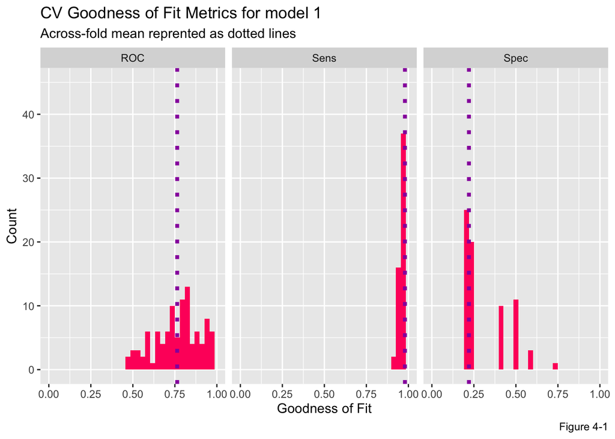

```r
dplyr::select(cvFit$resample, -Resample) %>%
  gather(metric, value) %>%
  left_join(gather(cvFit$results[2:4], metric, mean)) %>%
  ggplot(aes(value)) +
    geom_histogram(bins=35, fill = "#FF006A") +
    facet_wrap(~metric) +
    geom_vline(aes(xintercept = mean), colour = "#981FAC", linetype = 3, size = 1.5) +
    scale_x_continuous(limits = c(0, 1)) +
    labs(x="Goodness of Fit", y="Count", title="CV Goodness of Fit Metrics for model 1",
         subtitle = "Across-fold mean reprented as dotted lines",
         caption = "Figure 4-1")
```

```r
ctrl <- trainControl(method = "cv", number = 100, classProbs=TRUE, summaryFunction=twoClassSummary)

cvFit <- train(y ~ .,
                  data=Subsidy %>% na.omit()%>%
                    dplyr::select(-CreditNumeric, -X, -y_numeric, -age, -education, -pdays, -month),
                method="glm", family="binomial",
                metric="ROC", trControl = ctrl) # AUC = ROC

cvFit
```

```
## Generalized Linear Model
##
## 4116 samples
##   19 predictor
##    2 classes: 'no', 'yes'
##
## No pre-processing
## Resampling: Cross-Validated (100 fold)
## Summary of sample sizes: 4074, 4075, 4074, 4075, 4075, 4075, ...
## Resampling results:
##
##   ROC        Sens       Spec
##   0.7666843  0.9836186  0.21
```

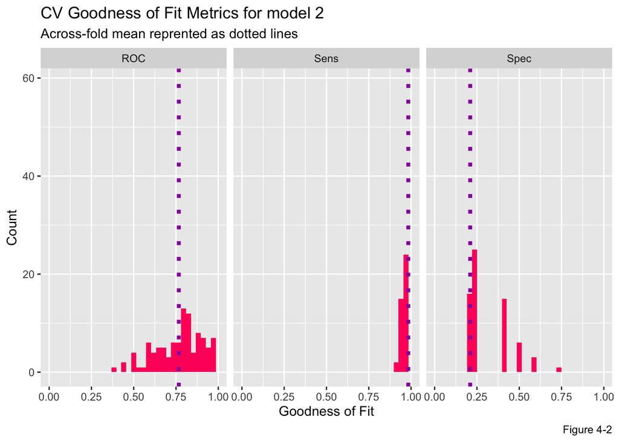

```r
dplyr::select(cvFit$resample, -Resample) %>%
  gather(metric, value) %>%
  left_join(gather(cvFit$results[2:4], metric, mean)) %>%
  ggplot(aes(value)) +
    geom_histogram(bins=35, fill = "#FF006A") +
    facet_wrap(~metric) +
    geom_vline(aes(xintercept = mean), colour = "#981FAC", linetype = 3, size = 1.5) +
    scale_x_continuous(limits = c(0, 1)) +
    labs(x="Goodness of Fit", y="Count", title="CV Goodness of Fit Metrics for model 2",
         subtitle = "Across-fold mean reprented as dotted lines",
         caption = "Figure 4-2")
```

# 5 Make prediction

To prediction for `SubsidyTest` is a better approach to goodness to fit. First, I created a data frame of test set probabilities, `testProbs`, which includes both the observed households’ choices about whether to receive the credit or not and predicted probabilities for each observation. This predictions are the estimated probabilities of taking credit for the out-of-sample subjects. I will compare them to the observed outcome.

```r
testProbs <- data.frame(Outcome = as.factor(SubsidyTest$CreditNumeric),
                        Probs = predict(SubsidyModel2, SubsidyTest, type= "response"))

head(testProbs)
```

```
##    Outcome      Probs
## 5        0 0.08098784
## 6        0 0.18708537
## 9        0 0.03876598
## 10       0 0.04963056
## 13       0 0.05430184
## 15       0 0.15116818
```

Figure 5-1 shows the distribution of predicted probabilities (x-axis) for receiving the credit or not, recoded as `1` and `0`(y-axis), respectively. If the regression model was very predictive, the ‘hump’ of predicted probabilities for `Credit` would around `1` on the x-axis, while the predicted probabilities for `No credit` would cluster around `0`. However, there seems no value cluster around `1` in `Credit` figure, that is the predictions of regression model might not that pleasant.

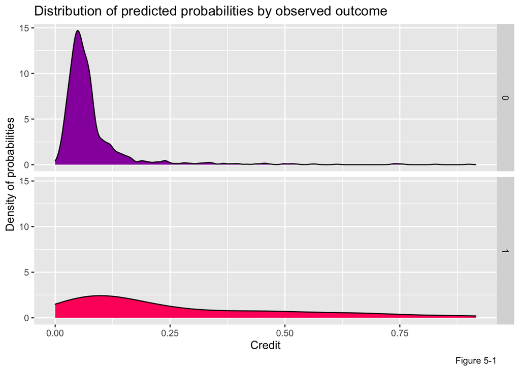

```r
ggplot(testProbs, aes(x = Probs, fill = as.factor(Outcome))) +
  geom_density() +
  facet_grid(Outcome ~ .) +
  scale_fill_manual(values = palette2) +
  labs(x = "Credit", y = "Density of probabilities",
       title = "Distribution of predicted probabilities by observed outcome",
        caption = "Figure 5-1") +
  theme(strip.text.x = element_text(size = 18),
        legend.position = "none")
```

Next, I created a variable called `predOutcome` which classifies any predicted probability greater than 0.5 as a predicted `Credit` event. That to say I created threshold of 50%.

```r
testProbs <-
  testProbs %>%
  mutate(predOutcome  = as.factor(ifelse(testProbs$Probs > 0.5 , 1, 0))) %>%
  na.omit()

head(testProbs)
```

```
##    Outcome      Probs predOutcome
## 5        0 0.08098784           0
## 6        0 0.18708537           0
## 9        0 0.03876598           0
## 10       0 0.04963056           0
## 13       0 0.05430184           0
## 15       0 0.15116818           0
```

```r
caret::confusionMatrix(testProbs$predOutcome, testProbs$Outcome,
                       positive = "1")
```

```
## Confusion Matrix and Statistics
##
##           Reference
## Prediction    0    1
##          0 1270  126
##          1   12   30
##
##                Accuracy : 0.904
##                  95% CI : (0.8876, 0.9188)
##     No Information Rate : 0.8915
##     P-Value [Acc > NIR] : 0.06704
##
##                   Kappa : 0.2694
##
##  Mcnemar's Test P-Value : < 0.0000000000000002
##
##             Sensitivity : 0.19231
##             Specificity : 0.99064
##          Pos Pred Value : 0.71429
##          Neg Pred Value : 0.90974
##              Prevalence : 0.10848
##          Detection Rate : 0.02086
##    Detection Prevalence : 0.02921
##       Balanced Accuracy : 0.59147
##
##        'Positive' Class : 1
##
```

Here the Accuracy calculated by the confusion matrix is 0.904, that to say the number of true positives plus true negatives divided by the total number of observations is 90.4%.

The Sensitivity and Specificity of SubsidyModel2 is 19.2% and 99.1%, respectively. Which means, the regression model is good at predicting those who are not going to receive credit. However, it should be do better at predicting the `Credit` outcome.

The possible methods to improve the model could be new features, better feature engineering and a more powerful predictive algorithm. Another approach for improving the model is to search for an ‘optional’ threshold that can limit the most costly errors.

# 6 ROC curve

The code block below uses the `plotROC` and `ggplot` packages to create a ROC curve for the SubsidyModel2.

The y-axis of the ROC curve (Figure 6-1) shows the rate of true positives (correctly predicted will receive credit) for each threshold from 0.01 to 1. The x-axis shows the rate of false positives (predicted will receive credit and household didn’t) for each threshold.

Follow the y-axis to about 0.6 and then across to the orange curve. According to the ROC Curve, a threshold that predicts Credit correctly 60% of the time, will predict `Creidt` incorrectly >10% of the time. Moving from a 60% to a 90% true positive rate dramatically increases the false positive rate.

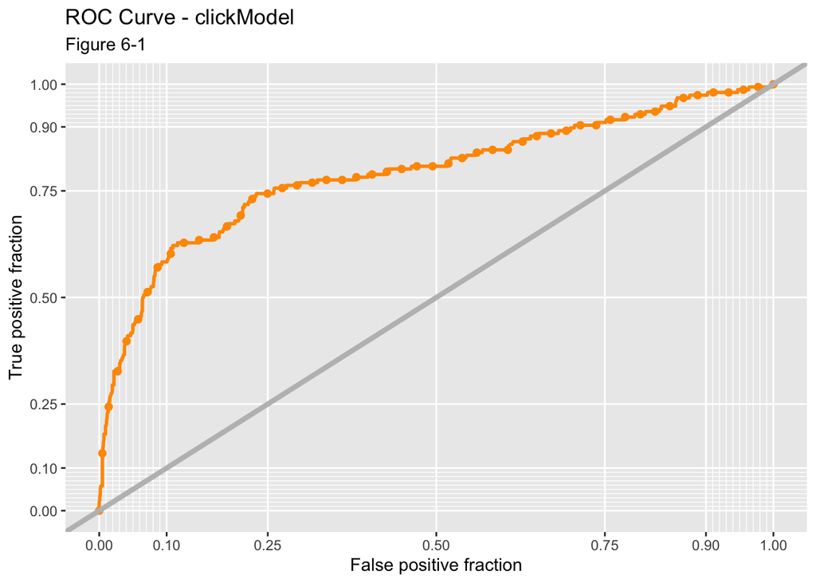

```r
ggplot(testProbs, aes(d = as.numeric(Outcome), m = Probs)) +
  geom_roc(n.cuts = 50, labels = FALSE, colour = "#FE9900") +
  style_roc(theme = theme_grey) +
  geom_abline(slope = 1, intercept = 0, size = 1.5, color = 'grey') +
  labs(title = "ROC Curve - clickModel",
       subtitle = "Figure 6-1")
```

Under the Curve’ metric or AUC for SubsidyModel2 is 0.7916.

```r
auc(testProbs$Outcome, testProbs$Probs)
```

```
## Area under the curve: 0.7916
```

# 7 Cost benefit analysis

## 7.1 Generating costs and benefits

Our goal is to target those household who will receive the credit. Assuming the model successfully predicts household will take the credit, and assuming a 2,850 dollars will be allocated to each household as marketing allocation. Given the new targeting algorithm, 25% of these households will receive 5,000 dollars credit at last while 75% will give up after receiving marketing allocation. According to evaluation by academic research in Philadelphia, houses that transacted after the credit sold 10,000 dollars higher on average.

Revenue and cost for each confusion metric can be explained and calculated as below:

<1>True Positive: Predicted correctly homeowner would enter credit program; allocated the marketing resources, and 25% ultimately achieved the credit. $Revenue = (10000 - 2850 - 5000 + 56000) * count * 0.25 - (2850) * count *0.75$

<2>True Negative: Predicted correctly homeowner would not take the credit, no marketing resources were allocated, and no credit was allocated. $Cost = 0 * count$

<3>False Positive: Predicted incorrectly homeowner would take the credit; allocated marketing resources; no credit allocated. $Cost = 2850 * count$

<4>False Negative: We predicted that a homeowner would not take the credit but they did. These are likely homeowners who signed up for reasons unrelated to the marketing campaign. Thus, we ‘0 out’ this category, assuming the cost/benefit of this is $0. $Revenun = 0 * count$

With equations above, cost benefit analysis for each confusion metrics is calculated in table below.

```r
cost_benefit_table <-
   testProbs %>%na.omit()%>%
      count(predOutcome, Outcome) %>%
      summarize(True_Negative = sum(n[predOutcome==0 & Outcome==0]),
                True_Positive = sum(n[predOutcome==1 & Outcome==1]),
                False_Negative = sum(n[predOutcome==0 & Outcome==1]),
                False_Positive = sum(n[predOutcome==1 & Outcome==0])) %>%
       gather(Variable, Count) %>%
       mutate(Revenue =
                case_when(Variable == "True_Negative"  ~ Count * 0,
                         Variable == "True_Positive"  ~ ((10000 - 2850 - 5000 + 56000) * Count * 0.25 - (2850) * Count *0.75),
                         Variable == "False_Negative" ~ 0 * Count,
                         Variable == "False_Positive" ~ (-2850) * Count)) %>%
    bind_cols(data.frame(Description = c(
              "We correctly predicted won't receive credit",
              "We correctly predicted will receive credit",
              "We predicted won't receive credit and household received",
              "We predicted will receive credit and household didn't")))

kable(cost_benefit_table,
       caption = "Cost/Benefit Table") %>% kable_styling()
```

Cost/Benefit Table

| Variable | Count | Revenue | Description |
| --- | --- | --- | --- |
| True_Negative | 1270 | 0 | We correctly predicted won’t receive credit |
| True_Positive | 30 | 372000 | We correctly predicted will receive credit |
| False_Negative | 126 | 0 | We predicted won’t receive credit and household received |
| False_Positive | 12 | -34200 | We predicted will receive credit and household didn’t |

Assuming our algorithm was used, the total `Cost`(column sun) in the Cost/Benefit Table above is $337,800.

## 7.2 Threshold as a function of total revenue and total count of credits

A different confusion matrix set of errors and cost/benefit calculation exists for each threshold, an ideal threshold is the one that achieve the most benefits. In this section, I will calculate confusion metrics of each threshold and total revenue for each.

Code below run the `iterateThresholds` function. Each row of table is a different `Threshold`.

```r
whichThreshold <-
  iterateThresholds(
     data=testProbs, observedClass = Outcome, predictedProbs = Probs)

whichThreshold[1:5,]
```

```
## # A tibble: 5 × 10
##   Count_TN Count_TP Count_FN Count_FP Rate_TP Rate_FP Rate_FN Rate_TN Accuracy
##      <int>    <int>    <int>    <int>   <dbl>   <dbl>   <dbl>   <dbl>    <dbl>
## 1       10      155        1     1272   0.994   0.992 0.00641 0.00780    0.115
## 2       45      155        1     1237   0.994   0.965 0.00641 0.0351     0.139
## 3      140      152        4     1142   0.974   0.891 0.0256  0.109      0.203
## 4      278      144       12     1004   0.923   0.783 0.0769  0.217      0.293
## 5      471      136       20      811   0.872   0.633 0.128   0.367      0.422
## # … with 1 more variable: Threshold <dbl>
```

With table above, Figure 7-1 plots threshold as a function of total revenue.

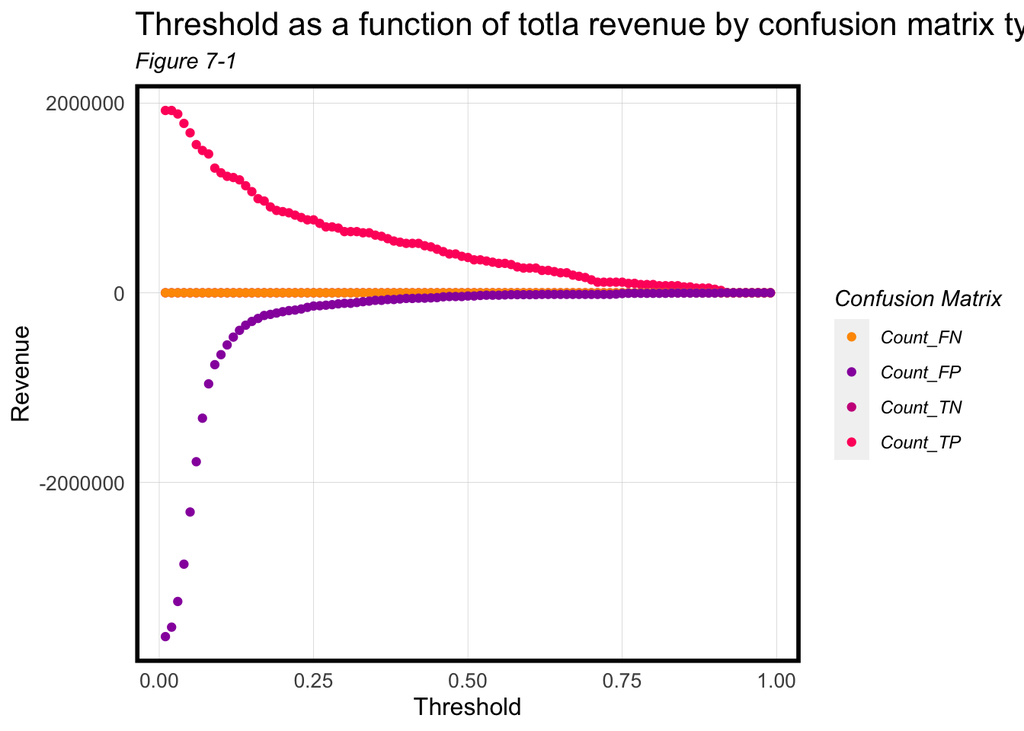

```r
whichThreshold <-
  whichThreshold %>%
    dplyr::select(starts_with("Count"), Threshold) %>%
    gather(Variable, Count, -Threshold) %>%
    mutate(Revenue =
             case_when(Variable == "Count_TN"  ~ Count * 0,
                       Variable == "Count_TP"  ~ ((10000 - 2850 - 5000 + 56000) * Count * 0.25 - (2850) * Count *0.75) ,
                       Variable == "Count_FN"  ~ 0 * Count,
                       Variable == "Count_FP"  ~ (-2850) * Count))

whichThreshold %>%
  ggplot(.,aes(Threshold, Revenue, colour = Variable)) +
  geom_point() +
  scale_colour_manual(values = palette5[c(5, 1:3)]) +
  labs(title = "Threshold as a function of totla revenue by confusion matrix type",
       y = "Revenue",
       subtitle = "Figure 7-1") +
  plotTheme() +
  guides(colour=guide_legend(title = "Confusion Matrix"))
```

Figure 7-2 plots threshold as a function of total count of credits. As only 25% household who will receive credit after being allocated market allocation, the total count of credits should be $Count_TP * 0.25$.

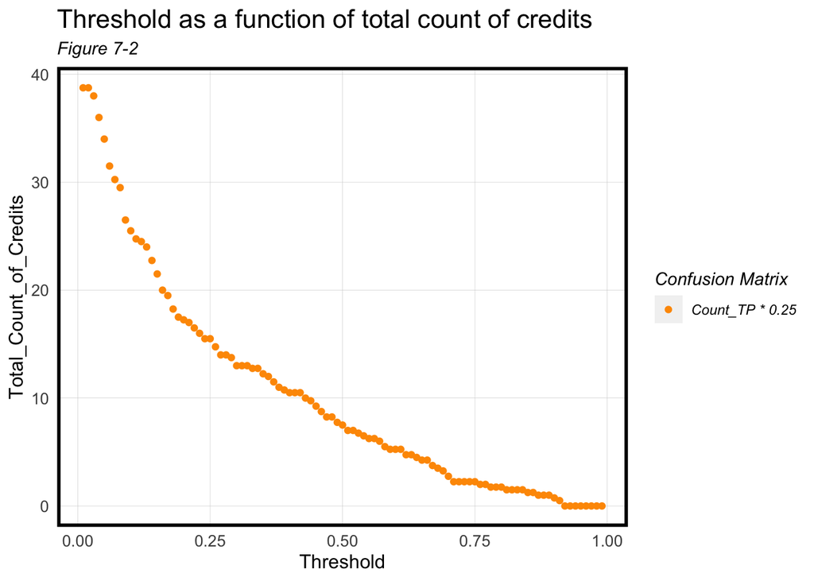

```r
whichThreshold <-
  whichThreshold %>%
  mutate(Total_Count_of_Credits = case_when(Variable == "Count_TP" ~ Count * 0.25))

whichThreshold %>%
  ggplot(aes(Threshold, Total_Count_of_Credits, colour = "Count_TP * 0.25")) +
  geom_point() +
  scale_colour_manual(values = palette5[c(5, 1:3)]) +
  labs(title = "Threshold as a function of total count of credits",
       y = "Total_Count_of_Credits",
       subtitle = "Figure 7-2") +
  plotTheme() +
  guides(colour=guide_legend(title = "Confusion Matrix"))
```

## 7.3 Optimizing the cost/benefit relationship

The next step of the cost/benefit analysis is to calculate the total `Revenue` across confusion metrics for each threshold.

```r
whichThreshold[is.na(whichThreshold)] <- 0

whichThreshold_revenue <-
whichThreshold %>%
    group_by(Threshold) %>%
    summarize(Revenue = sum(Revenue),
              Total_Count_of_Credits = sum(Total_Count_of_Credits))

whichThreshold_revenue[1:5,]
```

```
## # A tibble: 5 × 3
##   Threshold  Revenue Total_Count_of_Credits
##       <dbl>    <dbl>                  <dbl>
## 1      0.01 -1703200                   38.8
## 2      0.02 -1603450                   38.8
## 3      0.03 -1369900                   38
## 4      0.04 -1075800                   36
## 5      0.05  -624950                   34
```

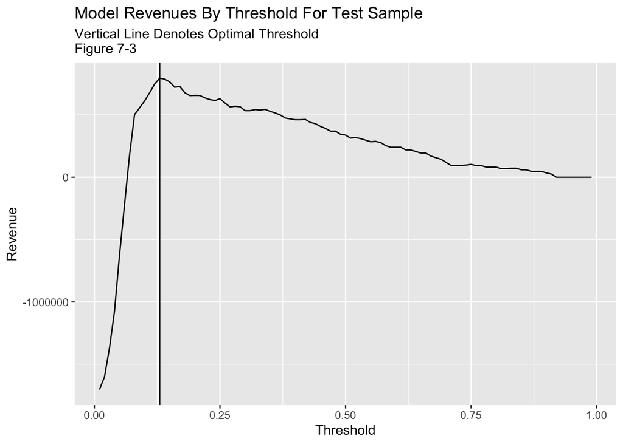

```r
Optimal_Threshold = arrange(whichThreshold_revenue, -Revenue)[1,1]

  ggplot(whichThreshold_revenue)+
  geom_line(aes(x = Threshold, y = Revenue))+
  geom_vline(xintercept =  pull(arrange(whichThreshold_revenue, -Revenue)[1,1]))+
    labs(title = "Model Revenues By Threshold For Test Sample",
         subtitle = "Vertical Line Denotes Optimal Threshold \nFigure 7-3")
```

```r
print(Optimal_Threshold)
```

```
## # A tibble: 1 × 1
##   Threshold
##       <dbl>
## 1      0.13
```

Table below shows the `Revenue` and the `Total_Count_of_Credits`, the default 50% threshold and the optimal threshold.

```r
Threshold_table <-
  subset(whichThreshold_revenue, Threshold == 0.5 | Threshold == 0.13)


kable(Threshold_table,
       caption = "Table of Revenue and Total_Count_of_Credits") %>% kable_styling()
```

Table of Revenue and Total_Count_of_Credits

| Threshold | Revenue | Total_Count_of_Credits |
| --- | --- | --- |
| 0.13 | 794250 | 24.0 |
| 0.50 | 337800 | 7.5 |

# 8 Conclusion

The goal for this project is to help HCD targeting qualified home owners and maximize revenue by reducing the cost of marketing allocated on home owners who might not receive credit.

In conclusion, I don’t recommend this model to be put into production. To figure out household who will receive credit, `Sensitivity` is an important indicator. The higher `Sensitivity`, the better the model is at predicting `Credit`. However, `Sensitivity` of the model is only 0.19 means that the model does not have convincing prediction ability.

The most possible reason for this result is that the training data set does not contain too much data which `y = yes`. Another possible reason is that there is little correlation between the variables and the independent variable, for their P-values indicate that the correlation is not significant.

Given that there is only 25% of contacted eligible homeowners receive the credit, which is relatively low rate, improving the response rate of marketing materials is another important method to boost revenue. According to Figure 3-1, 3-2 and 3-3, households who are contacts before this campaign, with lower unemployment rate at time of campaign, full time resident in Philadelphia tend to receive credit at last. And household previously contacted by cellular also tend to receive. So prioritizing contact with homeowners who meet the above criteria may help improve response rates.